# Processing Observation Data from Learning Experiments

Lewis Marsh and Luis P. Prieto

06 July, 2018

This R Markdown report aims to summarise the analyses done on the observation data of several sessions of innovative learning activities, from which multimodal data has been gathered

Note: in order to compile this report and to run the `auto_encoder.R` file, one must install the `keras` package properly. I.e., one must call `install_keras()` prior to compiling/running.

# Observation data

## Preprocessing

The preprocessing is taken care by the R script in `src/processObservationData.R`. It consists of two main functions, `processObservationData` (to process the data of one session) and `processAllObservationData` (for multiple sessions).

The first of these two functions,

```
data <- processObservationData(raw_data,
                       date=as.POSIXct(strptime("10-01-2018", "%d-%m-%Y")),
                       project="Isle",
                       activitycol=F,
                       observercol=F,
                       namecols=c("timestamp","group",
                            "StudentA","StudentB","StudentC","StudentD"))
```

takes in a dataframe with the raw observation data, together with some other parameters about the structure of the raw dataset and expected columns in the processed dataset, and returns a clean data frame with the observations for each individual.

In the orginal data sheets, each entry lists the observation for a whole group of students (between 3 and 6 usually) and the observations are listed as a piece of (predefined) text, such as “Talking with their group peers to solve the task” or “Totally disengaged”.

In the output this is broken up into individual entries for each student, for which a student variable is introduced. Furthermore, each possible observation is turned into a boolean variable for each of these entries, which makes it easier to conduct further statistical analysis of the dataset. Also, a column with additional notes from the original dataframe is dropped in the output, as it is difficult to make use of in a statistical test, and a global ID is created for each student, using the date, group, student number in the group and the project name. This will be of use when merging several datasets with the second function.

As students undertook several tastks in some of the experiments/projects, the input variable “activitycol” indicates whether the function has to look for an extra activity column in the input data. This will be taken over one-to-one in the output or will be filled in with “Standard” if there was only one activity. Similarly, in some projects there were more than one observer placed onto each group to enable to test the reliability of the observers and the data they produce. The variable “observercol” tells the function whether there is a separate observer column to take over from the input data. Otherwise “1-A” is filled in for each observer.

The second function, `processAllObservationData` takes in a vector of URLs in which the GoogleDocs containing the experimental data are stored in. It reads the data from the online sheets and places them in a dataframe. By examining the names of the columns in the dataframe, it detects whether there are activity or observation columns. By inspecting the first time stamp, it determines the date of the experiment. It then cleans the data using the first function and adds it to the end of a larger dataframe which eventually gets returned after the function has iterated through all URLs.

### Example of Output

To exhibit what the functions do, there is a brief example. We are given a data frame taken from one of the GoogleDocs:

```r
raw_data[1,1:2]
```

```
##             Timestamp What group are you observing?
## 1 11/10/2017 10:18:07                       Group 1
```

```r
raw_data[1,3]
```

```
## [1] "Talking with their group peers to solve the task"
```

These are only two snippets of the data, as anything else would not fit onto this page. We see that the first two columns give a timestamp and the group. We furthermore see the oberservation for student A. There are 3 other students in the group with individual columns as well as a column for further comments.

By applying the `processObservationData` function, we then see how the student variable is created and the observations are turned from text into boolean values. Furthermore, the activity and observer column have been created which makes it easier to merge and compare this data with other datasets.

```r
processed_data <- processAllObservationData()
summary(processed_data)
```

```
##   timestamp            group             comments              student
##  Length:3966        Length:3966        Length:3966        Student A:923
##  Class :character   Class :character   Class :character   Student B:916
##  Mode  :character   Mode  :character   Mode  :character   Student C:907
##                                                           Student D:862
##                                                           Student E:298
##                                                           Student G: 17
##                                                           (Other)  : 43
##    disengaged         looking          talking         technology
##  Min.   :0.00000   Min.   :0.0000   Min.   :0.0000   Min.   :0.0000
##  1st Qu.:0.00000   1st Qu.:0.0000   1st Qu.:0.0000   1st Qu.:0.0000
##  Median :0.00000   Median :0.0000   Median :1.0000   Median :1.0000
##  Mean   :0.09657   Mean   :0.2325   Mean   :0.6626   Mean   :0.5414
##  3rd Qu.:0.00000   3rd Qu.:0.0000   3rd Qu.:1.0000   3rd Qu.:1.0000
##  Max.   :1.00000   Max.   :1.0000   Max.   :1.0000   Max.   :1.0000
##
##    resources         external       student.id          activity
##  Min.   :0.0000   Min.   :0.0000   Length:3966        Length:3966
##  1st Qu.:0.0000   1st Qu.:0.0000   Class :character   Class :character
##  Median :0.0000   Median :0.0000   Mode  :character   Mode  :character
##  Mean   :0.3555   Mean   :0.2998
##  3rd Qu.:1.0000   3rd Qu.:1.0000
##  Max.   :1.0000   Max.   :1.0000
##
##    observer                    project          date
##  Length:3966        Ile Mysterieuse:1715   Min.   :2017-08-11 00:00:00
##  Class :character   Keha           : 170   1st Qu.:2017-10-11 00:00:00
##  Mode  :character   Linnarum       :1351   Median :2017-11-22 00:00:00
##                     NA's           : 730   Mean   :2017-11-04 00:17:42
##                                            3rd Qu.:2017-12-06 00:00:00
##                                            Max.   :2018-01-10 00:00:00
##
##   global.id
##  Length:3966
##  Class :character
##  Mode  :character
##
##
##
##
```

```r
str(processed_data)
```

```
## 'data.frame':    3966 obs. of  16 variables:
##  $ timestamp : chr  "11/10/2017 10:18:07" "11/10/2017 10:25:51" "11/10/2017 10:28:37" "11/10/2017 10:32:12" ...
##  $ group     : chr  "Group 1" "Group 1" "Group 1" "Group 1" ...
##  $ comments  : chr  "everybody is working, dont know the letters of members yet" "red hair deals with technology, the guy is a bit less active" "they all fiddle with their devices and try to observe the maps, dont want to look via computer, reimo comes and"| __truncated__ "my code red hair A and …
##  $ student   : Factor w/ 10 levels "Student A","Student B",..: 1 1 1 1 1 1 1 1 1 1 ...
##  $ disengaged: num  0 0 0 0 0 0 0 0 0 0 ...
##  $ looking   : num  0 0 0 0 0 0 0 0 0 0 ...
##  $ talking   : num  1 1 0 1 1 1 0 0 0 0 ...
##  $ technology: num  0 1 1 1 0 0 1 1 1 0 ...
##  $ resources : num  0 1 1 1 0 0 1 1 1 0 ...
##  $ external  : num  0 0 0 0 0 0 0 0 0 1 ...
##  $ student.id: chr  "Group 1 Student A" "Group 1 Student A" "Group 1 Student A" "Group 1 Student A" ...
##  $ activity  : chr  NA NA NA NA ...
##  $ observer  : chr  NA NA NA NA ...
##  $ project   : Factor w/ 3 levels "Ile Mysterieuse",..: 3 3 3 3 3 3 3 3 3 3 ...
##  $ date      : POSIXct, format: "2017-10-11" "2017-10-11" ...
##  $ global.id : chr  "2017-10-11 Group 1 Student A" "2017-10-11 Group 1 Student A" "2017-10-11 Group 1 Student A" "2017-10-11 Group 1 Student A" ...
```

### Spot checking the data

Some tables to see what kind of data we have

```r
table(processed_data$date, processed_data$student)
```

```
##
##              Student A Student B Student C Student D Student E Student F
##   2017-08-11       160       161       160       161        87         0
##   2017-10-11       148       144       132       125       143         2
##   2017-10-18        28        28        29        24         6        14
##   2017-11-22       164       164       163       164         0         0
##   2017-12-06       169       169       169       166        62         0
##   2017-12-13       182       178       182       150         0         0
##   2018-01-10        72        72        72        72         0         0
##
##              Student G Student H Student I Student J
##   2017-08-11         1         0         0         0
##   2017-10-11         2         0         0         0
##   2017-10-18        14        12        10         5
##   2017-11-22         0         0         0         0
##   2017-12-06         0         0         0         0
##   2017-12-13         0         0         0         0
##   2018-01-10         0         0         0         0
```

## MCA

The `mca.R` contains several functions to create and interpret an MCA conducted on the idicator variables created above.

Firstly, `mca_analysis(data, plots = T)` returns an mca element of the `FactoMineR` package. It has the options to create several plots, such as a bar plot of the significance of each newly created MCA dimension, the variance of the old variables in the first two dimensions and the distribution of each variable from the data set across the first two dimensions. An example of the last instance:

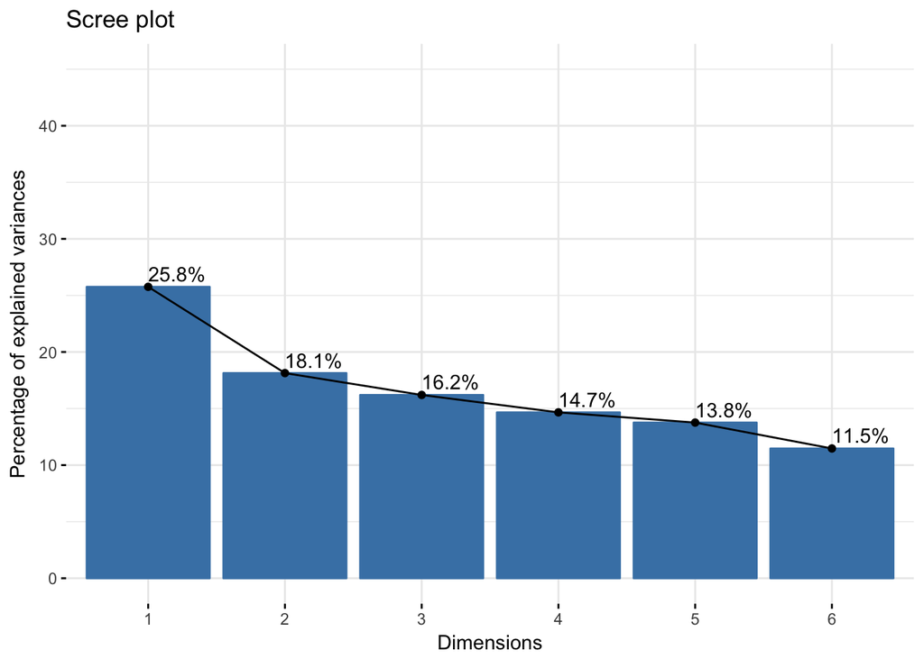

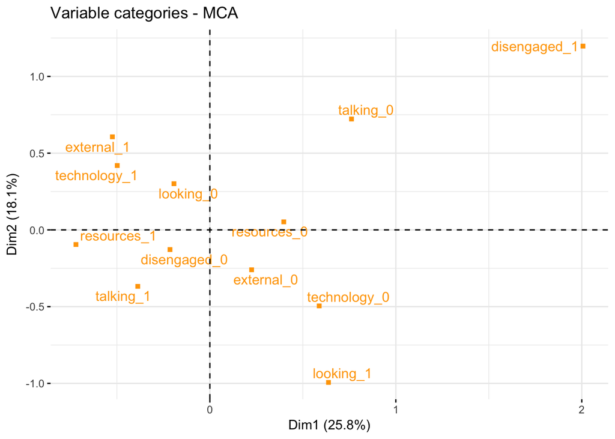

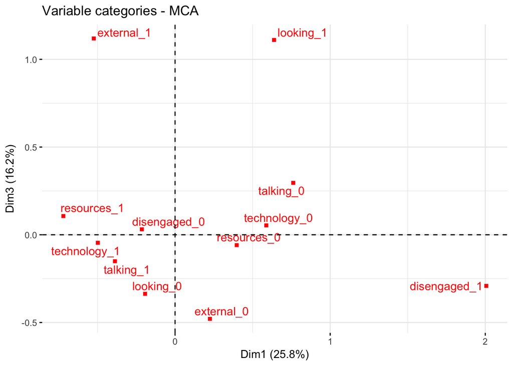

```r
  mca <- mca_analysis(processed_data, plots = T)
```

```r
#  fviz_ellipses(mca, "disengaged", geom = "point")
```

From these plots, we can see that **Dim1 could be interpreted as some general value of “(not) active engagement”**, while the other dimensions are harder to interpret from looking at the responses alone.

A further function is `add_mca_dimensions(dataframe, mca = NULL, dimensions = 3)`. It merges a chosen amount of dimension generated by the MCA into the original dataframe. One can choose whether one wants to generated the MCA object separately using the first functions (e.g. to inspect the plots first) or let the function conduct the MCA itself (if no mca is passed). For example:

```r
  processed_data <- add_mca_dimensions(processed_data, mca = mca, dimensions = 3)
```

There are several functions that visualise the distribution of our given data points. All of these take in a dataframe to which the MCA dimensions have been added.

For instance `create_dimension_histograms(dataframe, dimensions = 3)` creates a series of histograms that exhibit the distribution of data points on a desired amount of variables (by default the first 3). Similarly thereto, `reate_date_histograms(dataframe, dimension = 1)` creates histograms that show the distrbution of data points on a chosen dimension with each plot representing one day.

The information conatined in the histograms distingushing dates can also be shown in one single plot, using the `create_violin_plot` function. For our specific data set, this will looke like:

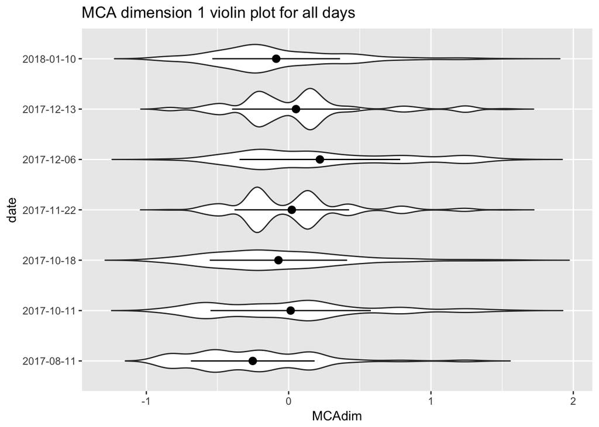

```r
  create_violin_plot(processed_data, dimension = 1)
```

Finally, the function `aggregate_by_groups(dataframe)` allows us to aggregate the dataframe on groups and timestamps, summing up the MCA dimension.

```r
  group_data <- aggregate_by_groups(processed_data)
  summary(group_data)
```

```
##   timestamp            group              MCAdim1
##  Length:978         Length:978         Min.   :-0.833460
##  Class :character   Class :character   1st Qu.:-0.251249
##  Mode  :character   Mode  :character   Median :-0.014889
##                                        Mean   :-0.002548
##                                        3rd Qu.: 0.191371
##                                        Max.   : 1.515658
##     MCAdim2             MCAdim3           activity
##  Min.   :-0.915523   Min.   :-0.56380   Length:978
##  1st Qu.:-0.255306   1st Qu.:-0.24531   Class :character
##  Median :-0.012123   Median :-0.03914   Mode  :character
##  Mean   : 0.001658   Mean   : 0.01548
##  3rd Qu.: 0.264379   3rd Qu.: 0.25163
##  Max.   : 0.952174   Max.   : 1.05644
##    observer                    project         date
##  Length:978         Ile Mysterieuse:423   Min.   :2017-08-11 00:00:00
##  Class :character   Keha           : 76   1st Qu.:2017-10-11 00:00:00
##  Mode  :character   Linnarum       :316   Median :2017-11-22 00:00:00
##                     NA's           :163   Mean   :2017-11-05 12:36:30
##                                           3rd Qu.:2017-12-13 00:00:00
##                                           Max.   :2018-01-10 00:00:00
##    comments
##  Length:978
##  Class :character
##  Mode  :character
##
##
##
```

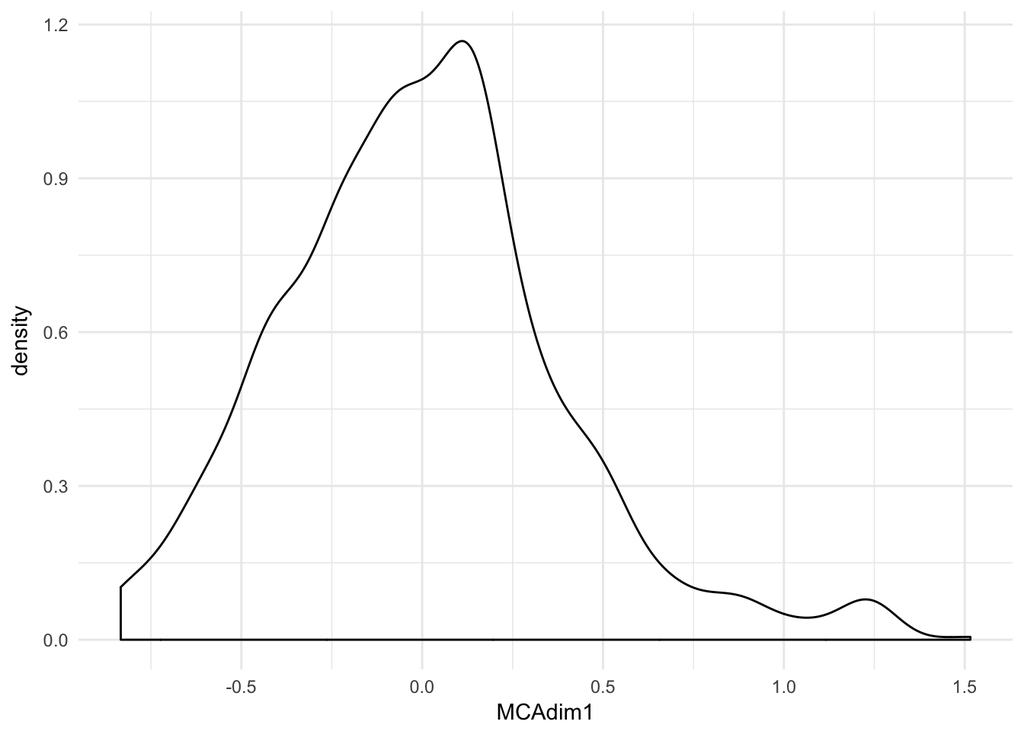

```r
  group_data %>%
    ggplot(aes(x = MCAdim1)) +
    theme_minimal() +
    geom_density()
```

## Visual inspection of observer comments

Let’s take a look at the observer comments for the highest-lowest values of this “(not) active engagement”:

```r
group_data %>%
  filter(!is.na(.data$comments)) %>%
  filter(MCAdim1 > 1.2) %>%
  dplyr::select(.data$MCAdim1,.data$comments) %>%
  kable
```

| timestamp | MCAdim1 | comments |
| --- | --- | --- |
| 06/12/2017 11:22:37 | 1.242748 | Task has been completed. Again after few minutes, teacher come and instruct to do something on Graasp. |
| 06/12/2017 11:55:01 | 1.242748 | They make a break with group 3 to eat some food. Coming back at 12:10 |
| 06/12/2017 12:00:22 | 1.242748 | The other group completely broke down, came to this group table. they are now all mostly off task, playing with some pottery tablet app. |
| 06/12/2017 12:05:02 | 1.242748 | Still playing, off task |
| 06/12/2017 13:44:07 | 1.242748 | They are playing with the devices. No activity is being done. They are totally out of scope. Group3 and 5 are all out of task. The mutual example doesn’t help. |
| 11/10/2017 10:44:36 | 1.242748 | Moving |
| 13/12/2017 11:15:27 | 1.242748 | Still waiting, looking at their phones mostly. |
| 13/12/2017 11:24:11 | 1.242748 | Still waiting, looking at their phones. D is even talking with girls from another group. Playing with the chairs. Some even try to leave the room, having a snack. |
| 22/11/2017 11:42:12 | 1.242748 | Buying stuff in supermarket? |
| 22/11/2017 11:56:01 | 1.242748 | Trammis |
| 22/11/2017 11:59:16 | 1.242748 | Coming back in the tram |

```r
group_data %>%
  filter(!is.na(.data$comments)) %>%
  filter(MCAdim1 < -0.6) %>%
  dplyr::select(.data$MCAdim1,.data$comments) %>%
  kable
```

| timestamp | MCAdim1 | comments |
| --- | --- | --- |
| 06/12/2017 10:26:02 | -0.6499529 | B takes her own phone to have an extra device. A opens Graasp with the one tablet. Edna comes to explain them how to deal with Graasp |
| 11/10/2017 10:34:57 | -0.8334601 | The group is trying to solve a problem, all talking but little, now external people came |
| 11/10/2017 11:15:31 | -0.6542174 | They all look to their phones. Maybe answering the questions? A person explains them some things about nearby buildings. |
| 11/10/2017 11:15:53 | -0.6887316 | The students talk with a peer from another group. |
| 11/8/2017 11:55:26 | -0.6367698 | koik tootavad nii laoratoorsete vahenditega kui ka padidega, opetaja kaib aitamas fyysiliselt a,b,c gruppi |
| 13/12/2017 10:23:45 | -0.6291677 | Teacher is giving some instruction. |
| 13/12/2017 11:25:23 | -0.8334601 | QR cod scan, do task, listen sound |
| 13/12/2017 13:06:54 | -0.6499529 | Meeskonnatoo, ruhmatoo, ruhm 4 liikmeline |
| 13/12/2017 13:12:59 | -0.7111220 | Asking to me that where they are supposed to write the answer. |
| 13/12/2017 13:36:14 | -0.6052514 | Collaboration |
| 18/10/2017 13:02:30 | -0.6970051 | Talking to teacher about form submission |
| 18/10/2017 13:34:41 | -0.7105286 | Using torch from mobile phone to look iside cartoon |

We see that largely, in the first comments the groups are largely disengaged or doing off-task stuff. And conversely, the second ones are mostly about groups largely working on tasks (even if they have problems in doing so)

## Topic modeling of observer comments

We can also do some unsupervised learning on the open comments left by the observers, to try and see if there are certain kinds of words/topics that are distinctly important in them:

```
## fit models... done.
## calculate metrics:
##   Griffiths2004... done.
##   CaoJuan2009... done.
##   Arun2010... done.
##   Deveaud2014... done.
```

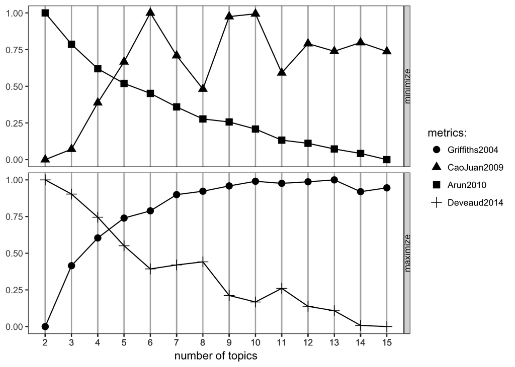

```r
source("../src/lda.R")

plotNrTopics(docids = paste(group_data$timestamp,group_data$student),texts = group_data$comments, addstop = c(NA,"group"))
```

```r
lda <- getLDA(docids = paste(group_data$timestamp,group_data$student),texts = group_data$comments, addstop = c(NA,"group"), k = 2)
```

```
## [1] "Top topic terms"
## # A tibble: 8 x 3
##   topic term       beta
##   <int> <chr>     <dbl>
## 1     1 teacher  0.0566
## 2     1 working  0.0394
## 3     1 students 0.0255
## 4     1 task     0.0249
## 5     2 teacher  0.0406
## 6     2 task     0.0281
## 7     2 back     0.0206
## 8     2 talk     0.0168
```

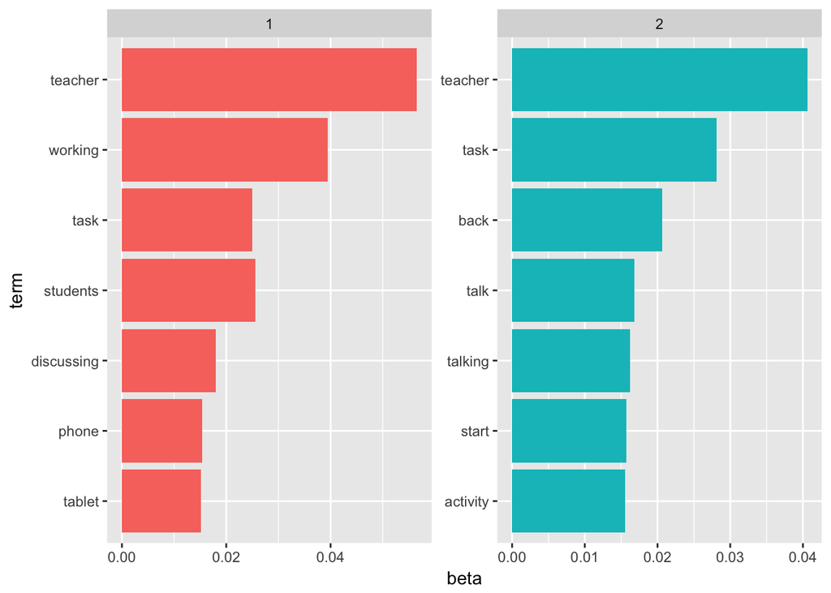

```r
labels <- getTopicLabels(lda, n = 7) # Topic names, based on the most important words

plotLDATopics(lda, n = 7)
```

```r
gammas <- tidy(lda, matrix = "gamma") # Probability of each document being in each topic

#detach("package:tidyverse", unload=TRUE)
```

## Hidden Markov Models in the Data Set

Another way of trying to detect structure in our data set is the theory of Hidden Markov Models. In the file `hmm.R` one can find several functions to generate Hidden Markov Models on our data set. The most central one is

```r
create_hmm_states_global(data, max_states = 3, sorted = F, visualise = T).
```

It takes in a preprocessed data set (possibly but not neccesarily with added MCA dimensions), a maximal number of states the function should try, an indicator if the data set is already sorted (by global.id and timestamp), and an option for a visualisation of how the function determined the best number of states. The function then returns a fitted HMM model of the `depmix` class. We exhibit an example of such a visulisation here (although we do not use the function to reduce computational expense):

```r
# This currently takes about 10 min to run. 7 states become too computationally expensive
create_hmm_states_global(processed_data, visualise = TRUE, max_states = 6)
```

```
## converged at iteration 1 with logLik: -13668.08
## converged at iteration 81 with logLik: -12857.04
## converged at iteration 55 with logLik: -12489.29
## converged at iteration 136 with logLik: -12246.67
## converged at iteration 164 with logLik: -11983.82
## converged at iteration 146 with logLik: -11772.58
```

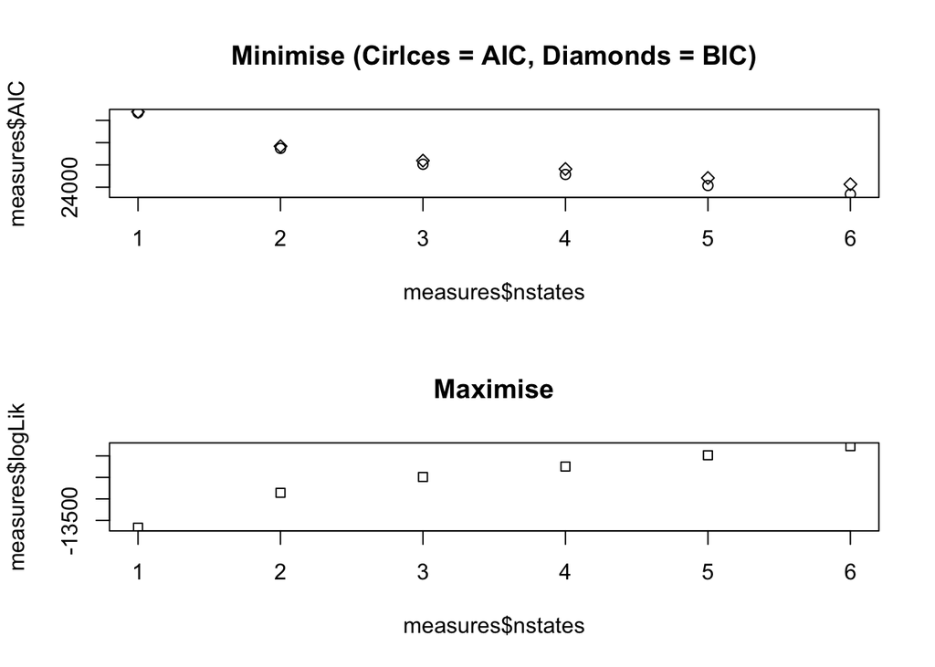

```
## Convergence info: Log likelihood converged to within tol. (relative change)
## 'log Lik.' -11772.58 (df=71)
## AIC:  23687.15
## BIC:  24133.33
```

Alternatively, it is also possible to train a Hidden Markov Model on the timeseries of merely one student, if this is desired. The function to use is `create_hmm_states_student(data, globalid, max_iterations = 3)`.

Furthermore, it is possible to add the transition probabilities and predicted states to the data set, using the function `insert_hmm(data, initial_state = 1)`. It requires an initial state of the model to be passed on in order to make the predictions. Especially if little information on what the states represent is available, this might have to be guessed.

Finally, the function `plot_development_by_student(data, globalid)` allows to compare the first MCA dimension with the transition through the different HMM states. As arguments a preprocessed data set augmented by MCA dimensions and HMM states, as well as the global.id of the chosen student are required. This is exhibited by an example here:

```r
processed_data <- add_mca_dimensions(processed_data)
processed_data <- insert_hmm(processed_data)
```

```
## converged at iteration 1 with logLik: -13668.08
## converged at iteration 86 with logLik: -12857.04
## converged at iteration 61 with logLik: -12489.29
```

[figure not shown]

```r
plot_development_by_student(processed_data, "Isle 2017-12-06 Group 2 Student D")
```

## Inspection of Created States

As the number of different states is quite modest, it turns out to be difficult to detect any kind of pattern in them through visual inspection. However, we may still draw some results from checing how the different observation variables are distributed over the states Using a model with three categories, we for example find:

```r
summary(cat1)
```

```
##    comments           disengaged        looking          talking
##  Length:934         Min.   :0.0000   Min.   :0.0000   Min.   :0.0000
##  Class :character   1st Qu.:0.0000   1st Qu.:0.0000   1st Qu.:0.0000
##  Mode  :character   Median :0.0000   Median :0.0000   Median :0.0000
##                     Mean   :0.3448   Mean   :0.3908   Mean   :0.2345
##                     3rd Qu.:1.0000   3rd Qu.:1.0000   3rd Qu.:0.0000
##                     Max.   :1.0000   Max.   :1.0000   Max.   :1.0000
##    technology       resources        external
##  Min.   :0.0000   Min.   :0.000   Min.   :0.0000
##  1st Qu.:0.0000   1st Qu.:0.000   1st Qu.:0.0000
##  Median :0.0000   Median :0.000   Median :0.0000
##  Mean   :0.2484   Mean   :0.152   Mean   :0.2281
##  3rd Qu.:0.0000   3rd Qu.:0.000   3rd Qu.:0.0000
##  Max.   :1.0000   Max.   :1.000   Max.   :1.0000
```

```r
summary(cat2)
```

```
##    comments           disengaged        looking          talking
##  Length:2086        Min.   :0.0000   Min.   :0.0000   Min.   :0.0000
##  Class :character   1st Qu.:0.0000   1st Qu.:0.0000   1st Qu.:0.0000
##  Mode  :character   Median :0.0000   Median :0.0000   Median :1.0000
##                     Mean   :0.0278   Mean   :0.1548   Mean   :0.7306
##                     3rd Qu.:0.0000   3rd Qu.:0.0000   3rd Qu.:1.0000
##                     Max.   :1.0000   Max.   :1.0000   Max.   :1.0000
##    technology       resources         external
##  Min.   :0.0000   Min.   :0.0000   Min.   :0.0000
##  1st Qu.:1.0000   1st Qu.:0.0000   1st Qu.:0.0000
##  Median :1.0000   Median :0.0000   Median :0.0000
##  Mean   :0.8768   Mean   :0.4334   Mean   :0.3926
##  3rd Qu.:1.0000   3rd Qu.:1.0000   3rd Qu.:1.0000
##  Max.   :1.0000   Max.   :1.0000   Max.   :1.0000
```

```r
summary(cat3)
```

```
##    comments           disengaged          looking          talking
##  Length:941         Min.   :0.000000   Min.   :0.0000   Min.   :0.0000
##  Class :character   1st Qu.:0.000000   1st Qu.:0.0000   1st Qu.:1.0000
##  Mode  :character   Median :0.000000   Median :0.0000   Median :1.0000
##                     Mean   :0.003188   Mean   :0.2487   Mean   :0.9384
##                     3rd Qu.:0.000000   3rd Qu.:0.0000   3rd Qu.:1.0000
##                     Max.   :1.000000   Max.   :1.0000   Max.   :1.0000
##    technology        resources         external
##  Min.   :0.00000   Min.   :0.0000   Min.   :0.0000
##  1st Qu.:0.00000   1st Qu.:0.0000   1st Qu.:0.0000
##  Median :0.00000   Median :0.0000   Median :0.0000
##  Mean   :0.08927   Mean   :0.3847   Mean   :0.1658
##  3rd Qu.:0.00000   3rd Qu.:1.0000   3rd Qu.:0.0000
##  Max.   :1.00000   Max.   :1.0000   Max.   :1.0000
```

Furthermore, we like to look at how the results of our HMM are correlated to the results of our MCA.

```r
cor(processed_data[,c("MCAdim1","MCAdim2","MCAdim3","HMMPredS","HMMS1","HMMS2","HMMS3")],
      use="complete.obs", method="kendall")
```

```
##              MCAdim1     MCAdim2     MCAdim3    HMMPredS       HMMS1
## MCAdim1   1.00000000  0.02282555  0.05704291 -0.24371794  0.69198355
## MCAdim2   0.02282555  1.00000000 -0.01752765 -0.33057757  0.03206965
## MCAdim3   0.05704291 -0.01752765  1.00000000 -0.15886164  0.09772111
## HMMPredS -0.24371794 -0.33057757 -0.15886164  1.00000000 -0.30159361
## HMMS1     0.69198355  0.03206965  0.09772111 -0.30159361  1.00000000
## HMMS2    -0.51339204  0.23347051  0.02482002  0.03884444 -0.59590478
## HMMS3    -0.04752463 -0.52546713 -0.15119450  0.46678283 -0.02903753
##                HMMS2       HMMS3
## MCAdim1  -0.51339204 -0.04752463
## MCAdim2   0.23347051 -0.52546713
## MCAdim3   0.02482002 -0.15119450
## HMMPredS  0.03884444  0.46678283
## HMMS1    -0.59590478 -0.02903753
## HMMS2     1.00000000 -0.36405661
## HMMS3    -0.36405661  1.00000000
```

Furthermore, we can see that the distribution of states is quite different accross the different days:

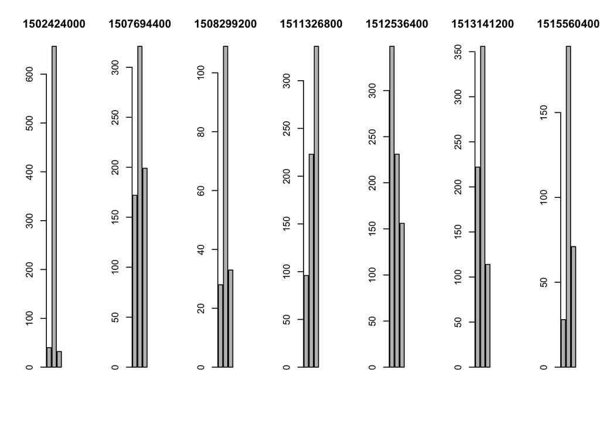

```r
par(mfrow=c(1,7))

for(day in unique(processed_data$date)){
  day_data <- subset(processed_data, date == day)[, c("date", "HMMPredS")]
  counts <- c(nrow(subset(day_data, HMMPredS == 1)),nrow(subset(day_data, HMMPredS == 2)),nrow(subset(day_data, HMMPredS == 3)))
  barplot(counts, main = day)
}
```

## Autoencoding

We can exhibit the behaviour of this function:

```r
training_and_test <- processed_data %>% filter(row_number() <= nrow(processed_data)*0.75)
validation <- processed_data %>% filter(row_number() > nrow(processed_data)*0.75)

model <- build_autoencoder(training_and_test)
```

```
## ___________________________________________________________________________
## Layer (type)                     Output Shape                  Param #
## ===========================================================================
## dense_1 (Dense)                  (None, 3)                     21
## ___________________________________________________________________________
## dense_2 (Dense)                  (None, 6)                     24
## ===========================================================================
## Total params: 45
## Trainable params: 45
## Non-trainable params: 0
## ___________________________________________________________________________
## NULL
```

```r
validation <- get_predictions(validation, model)

summary(validation$AEerr)
```

```
## Length  Class   Mode
##      0   NULL   NULL
```

We can build a sparse autoencoder using the function `build_sparse_autoencoder(data, units = 3)` and proceeding in the same way as above otherwise.

Once we are satisfied with our model, we can add the units of the hidden layer to our dataframe, using the `insert_ae_units(data, model, sparse = FALSE)` from the file.

```r
processed_data <- insert_ae_units(processed_data, model)
```

If the model is a different type of autoencoder (e.g. sparse), the `name` variable shoulde be set to a prefix that labels the columns correctly.

We can see that the new variables have a moderate correlation with the previously introduced MCA dimensions. This does not really come as a surprise, as both techniques are related to Principal Component Analysis (PCA).

```r
cor(processed_data[,c("MCAdim1","MCAdim2","MCAdim3","HMMPredS","AEdim1","AEdim2","AEdim3")], use="complete.obs", method="kendall")
```

```
##              MCAdim1     MCAdim2     MCAdim3    HMMPredS      AEdim1
## MCAdim1   1.00000000  0.02282555  0.05704291 -0.24371794  0.50438408
## MCAdim2   0.02282555  1.00000000 -0.01752765 -0.33057757 -0.17996554
## MCAdim3   0.05704291 -0.01752765  1.00000000 -0.15886164  0.05796122
## HMMPredS -0.24371794 -0.33057757 -0.15886164  1.00000000 -0.11243278
## AEdim1    0.50438408 -0.17996554  0.05796122 -0.11243278  1.00000000
## AEdim2   -0.04837447  0.68976002 -0.02387845 -0.19496170 -0.06645330
## AEdim3   -0.56166897  0.15950084  0.17761926  0.01729665 -0.29398440
##               AEdim2      AEdim3
## MCAdim1  -0.04837447 -0.56166897
## MCAdim2   0.68976002  0.15950084
## MCAdim3  -0.02387845  0.17761926
## HMMPredS -0.19496170  0.01729665
## AEdim1   -0.06645330 -0.29398440
## AEdim2    1.00000000  0.21995427
## AEdim3    0.21995427  1.00000000
```

Even though we already have a quite good idea of what the MCA dimensions represent, a visual inspection (not pictured) of the highest and lowest scoring comments of the auto encoder output variables does not suggest any trend in general and does not make a correlation with the MCA dimension visible in particular.

A slightly better fit is given by a sparse autoencoder with three units. Here, the interpretation is easier and the correlation with the MCA dimensions are stronger.

```r
model_sparse <- build_sparse_autoencoder(training_and_test)
processed_data <- insert_ae_units(processed_data, model_sparse, name = "Sp")

validation <- get_predictions(validation, model_sparse, type = "Sp")
```

```r
mean(validation$SpAEError)
```

```
## [1] 0.7325933
```

Visual inspection of comments and observer values shows that low values in the first sparse AE dimension correspond to active engagement in the task with a focus on group work, while high values represent disengaged students, who are possibly even engaging in external matters. High values in the second dimension seem to conicide with students who talking with others, opposed to low values which represent student who are focusing completely on the use of technology and other resources. The interpretation of the final variable proves to be a bit more difficult. On the two extreme ends, there are students who are disengaged and looking, and students who are everything else. This suggests that the third variable only gives us information that is already contained in the first two variables. However, a sparse autoencoder does not seem to a fruitful model of the data. There is a high negative correlation with the second MCA dimension:

```r
cor(processed_data[, c("SpAEdim1","SpAEdim2","SpAEdim3","MCAdim1","MCAdim2","MCAdim3")], method = "kendall")
```

```
##             SpAEdim1     SpAEdim2    SpAEdim3     MCAdim1     MCAdim2
## SpAEdim1  1.00000000 -0.134856141 -0.06011775  0.15128671  0.27188903
## SpAEdim2 -0.13485614  1.000000000  0.22491050  0.49801134 -0.43775236
## SpAEdim3 -0.06011775  0.224910496  1.00000000 -0.24924598 -0.63642478
## MCAdim1   0.15128671  0.498011338 -0.24924598  1.00000000  0.02282555
## MCAdim2   0.27188903 -0.437752364 -0.63642478  0.02282555  1.00000000
## MCAdim3  -0.64232282 -0.001273956 -0.28322254  0.05704291 -0.01752765
##               MCAdim3
## SpAEdim1 -0.642322825
## SpAEdim2 -0.001273956
## SpAEdim3 -0.283222544
## MCAdim1   0.057042909
## MCAdim2  -0.017527646
## MCAdim3   1.000000000
```

The (theoretical) advantage of a recurrent autoencoder is that unlike the other two types presented before, it respects the ordering in which the observations occurred.

```r
model_recurrent <- build_recurrent_autoencoder(training_and_test)
processed_data <- insert_ae_units(processed_data, model_recurrent, name = "Rec")

validation <- get_predictions(validation, model_recurrent, type = "Rec")

mean(validation$RecAEError)
```

```
## [1] 0.7588295
```

## Loading Questionnaires

In order to load the questionnaire data to an R dataframe, we have created the file `questionnaires.R`. It contains two functions of interest: `load_all_intermediate_questionnaires(urls, date_type)` and `load_all_final_questionnaires(urls, date_type)`. Both have all questionnaire urls as default arguments and return a single data frame containing the data of all questionnaires of a respective type. We exhibit its usage here:

```r
iq_data <- load_all_intermediate_questionnaires()
fq_data <- load_all_final_questionnaires()
```

In these two new data sets one will find columns called id. This is a unique identifier for each element in these dataframes and is used by the function `match_with_data(data, iq, fq)`, who adds columns to the observer dataset in which each observation is linked to the questionnaire data via the numbers in the id columns. These new columns are called int.questionnaire and fin.questionnaire.

```r
matched_data <- match_with_data(processed_data, iq=iq_data, fq=fq_data)
```

Once we have matched the data with the questionnaires, we can merge and aggregate the data by a function in the same file in the following way:

```r
agg_data <- merge_and_aggregate(matched_data, iq_data, fq_data)
```

The dataset given to this function must contain exactly three MCA dimension variables and exactly three autoencoder unit variables. If there are three spare autoencoder variables, one should use `agg_data <- merge_and_aggregate(matched_data, iq_data, fq_data, sparse = FALSE)`.

However, by visual inspection we can see that there is no particularly high correleation between any of the observer variables and the student response variables:

```r
cor(agg_data[, c("disengaged", "looking", "talking", "technology", "resources", "contribution", "difficulty", "prepared", "i_satisfaction", "f_satisfaction")], method = "kendall")
```

```
##                   disengaged     looking     talking  technology
## disengaged      1.0000000000  0.24227956 -0.24925637 -0.29467648
## looking         0.2422795566  1.00000000  0.07714820 -0.20864231
## talking        -0.2492563696  0.07714820  1.00000000  0.07159429
## technology     -0.2946764815 -0.20864231  0.07159429  1.00000000
## resources      -0.1686286354 -0.09008285  0.19733847  0.08985994
## contribution   -0.1542103911 -0.05210534 -0.13330690  0.08205957
## difficulty      0.0007078933 -0.03249266 -0.06149050  0.03001331
## prepared       -0.1531377875 -0.07128254 -0.05475901  0.04738433
## i_satisfaction -0.0714781465  0.24721245  0.03990339 -0.02410504
## f_satisfaction -0.0957371637  0.01495151 -0.09243140  0.08765009
##                  resources contribution    difficulty    prepared
## disengaged     -0.16862864  -0.15421039  0.0007078933 -0.15313779
## looking        -0.09008285  -0.05210534 -0.0324926599 -0.07128254
## talking         0.19733847  -0.13330690 -0.0614905028 -0.05475901
## technology      0.08985994   0.08205957  0.0300133063  0.04738433
## resources       1.00000000  -0.09026851 -0.0257574753  0.03847630
## contribution   -0.09026851   1.00000000  0.1204819302  0.37621001
## difficulty     -0.02575748   0.12048193  1.0000000000  0.02953664
## prepared        0.03847630   0.37621001  0.0295366406  1.00000000
## i_satisfaction  0.13528807   0.12024651 -0.1005342147  0.18587343
## f_satisfaction  0.02117150   0.15070533 -0.0669426688  0.03508599
##                i_satisfaction f_satisfaction
## disengaged        -0.07147815    -0.09573716
## looking            0.24721245     0.01495151
## talking            0.03990339    -0.09243140
## technology        -0.02410504     0.08765009
## resources          0.13528807     0.02117150
## contribution       0.12024651     0.15070533
## difficulty        -0.10053421    -0.06694267
## prepared           0.18587343     0.03508599
## i_satisfaction     1.00000000     0.19607744
## f_satisfaction     0.19607744     1.00000000
```

## Testing Reliability of Observers

In the file `reliability.R` we can find some useful tools to check the reliability of observers. Most important are the functions `test_cont_vars_for_observers(data, selected_columns)` and `test_discrete_vars_for_observers(data, selected_columns)`. Both take in a data frame generated by our preprocessing function, potentially with some added variables, and a vector which contains the names of the variables one wants to analyse. It returns an analysis that depends on whether the function for discrete or the function for continuous variables is used. In the discrete case in returns an analysis in terms of Cohen’s Kappa and Krippendorf’s alpha, while for continuous variables it only returns the latter. Note that continuous variables should be normalised using the `normalise(data, columns)` function and that the variables should be added to the data frame before the observations which have two different observers are filtred out. Otherwise, we cannot guarantee that the variables still have same meaning as we have interpreted before. We can see that for most variables there is a discrepancy between the two observers:

```r
test_discrete_vars_for_observers(processed_data, c("disengaged","looking","talking","technology","resources","external"))
```

```
##           var  group        kappa      kappa.p       alpha
## 1  disengaged Group1 -0.046728972 6.757417e-01 -0.04958678
## 2  disengaged Group2  0.394904459 1.531099e-05  0.37396352
## 3     looking Group1  0.310179641 5.198468e-03  0.28473091
## 4     looking Group2  0.382532160 3.505219e-04  0.36554622
## 5     talking Group1  0.073047859 4.926580e-01  0.02859993
## 6     talking Group2 -0.009661836 9.301810e-01 -0.01404151
## 7  technology Group1  0.466110532 1.091510e-04  0.46129374
## 8  technology Group2  0.522388060 1.827457e-06  0.51602564
## 9   resources Group1  0.430830040 5.117209e-04  0.43303571
## 10  resources Group2  0.651622003 2.766748e-09  0.64637002
## 11   external Group1  0.433628319 5.056356e-04  0.43743079
## 12   external Group2  0.346364347 2.357262e-03  0.34862745
```

```r
df <- normalise(processed_data, c("MCAdim1","MCAdim2","MCAdim3","AEdim1","AEdim2","AEdim3"))
test_cont_vars_for_observers(df, c("MCAdim1","MCAdim2","MCAdim3","AEdim1","AEdim2","AEdim3"))
```

```
##        var  group     alpha
## 1  MCAdim1 Group1 0.3980122
## 2     <NA> Group2 0.3984108
## 3  MCAdim2 Group1 0.4623139
## 4     <NA> Group2 0.5348614
## 5  MCAdim3 Group1 0.2681363
## 6     <NA> Group2 0.1920647
## 7   AEdim1 Group1 0.5179499
## 8     <NA> Group2 0.5460012
## 9   AEdim2 Group1 0.3724218
## 10    <NA> Group2 0.5852191
## 11  AEdim3 Group1 0.4501233
## 12    <NA> Group2 0.5487787
```

## Process Mining

In order to analyse common tranistion states, it is possible to perform some (visual) process mining on our data using the file `project_mining.R`. Firstly, the function

```r
preprocess_for_mining(data, obs.var =
                      c("disengaged", "looking", "talking", "technology", "resources", "external"))
```

takes in a data frame and preprocesses it for the process mining. One has to select the observer variables one wants to analyse. Especially if this is done visually it is wise to restrict to 3 or 4 variables at most. A data frame that is ready to be used for the project mining is returned.

The function, `plot_variants(data)` takes in a preprocessed data frame and plots the distribution of variants.

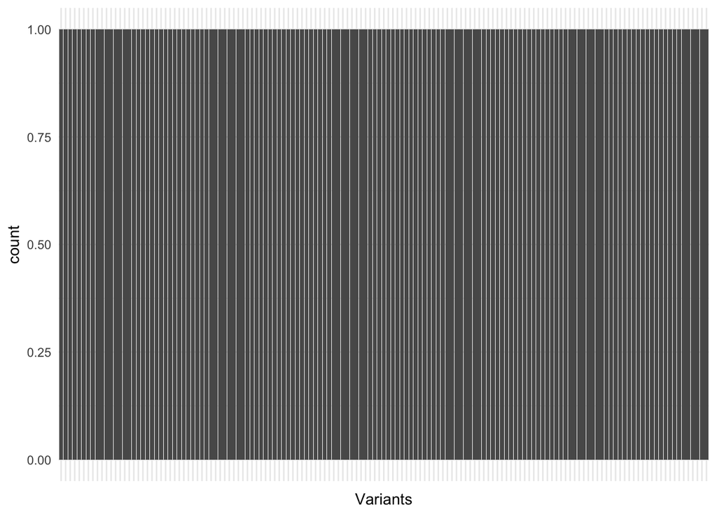

```r
pm_data <- preprocess_for_mining(processed_data)
plot_variants(pm_data)
```

According to kdnuggets.com, the bars of this plot ideally tail off. As they do not in our case, this model might not give as a lot of information.

Finally, the function `visualise_process_maps(data, plot = FALSE)` gives us an tranistion idea of the frequency of transitions between states and an optional plot of these. An example plotting the variables looking, talking and technology is given here:

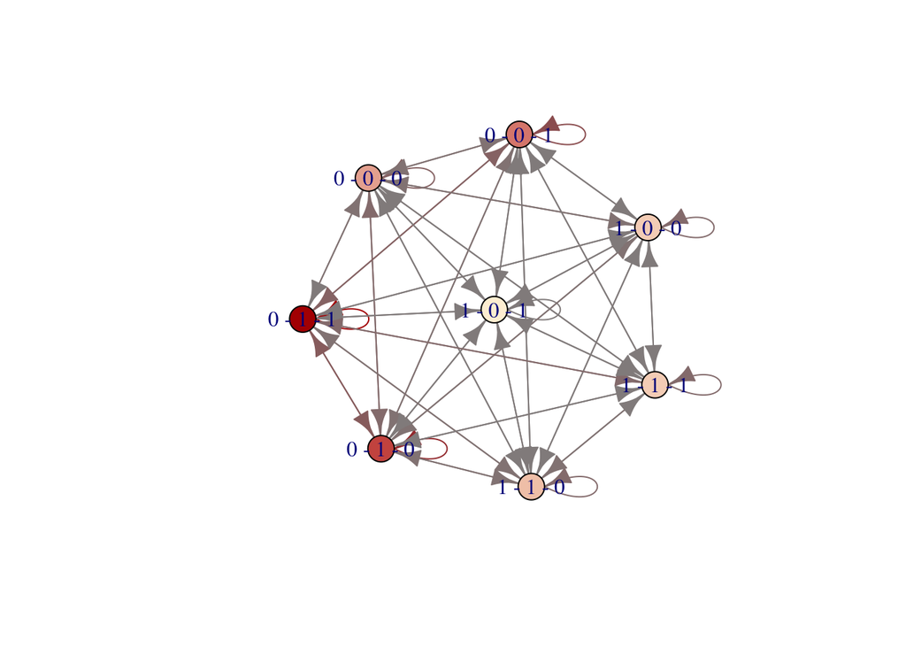

```r
pm_data <- preprocess_for_mining(processed_data, c("looking", "talking", "technology"))
transitions <- visualise_process_maps(pm_data, plot = T)
```

Similarly, we can use this to visualise the transitions between the HMM states:

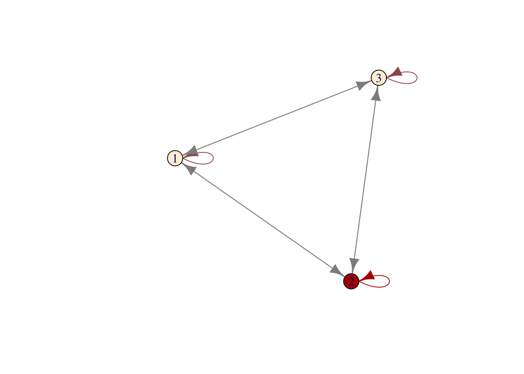

```r
pm_data <- preprocess_for_mining(processed_data, c("HMMPredS"))
transitions <- visualise_process_maps(pm_data, plot = T)
```

## Anomaly Detection

The script `anomaly_testing.R` contains functions to perform anomaly detection on our observation variables. The function `isolation_forest_per_student(data, threshold = 0.95, plot = T, normalise = T)` uses the machine learning techniques to detect students with anomal observation data. The function first (optionally) normalises the observation values within one project day and then aggregates (and averages) the data. The function then returns a data frame containing students, their aggregated observation data, as well as an anomaly score and an anomaly indicator. The threshold for the latter can be set by an input parameter of the function (the input value represents the proportion of students that are normal). Optionally, one can include explantory plots.

```r
if_data <- isolation_forest_per_student(processed_data)
```

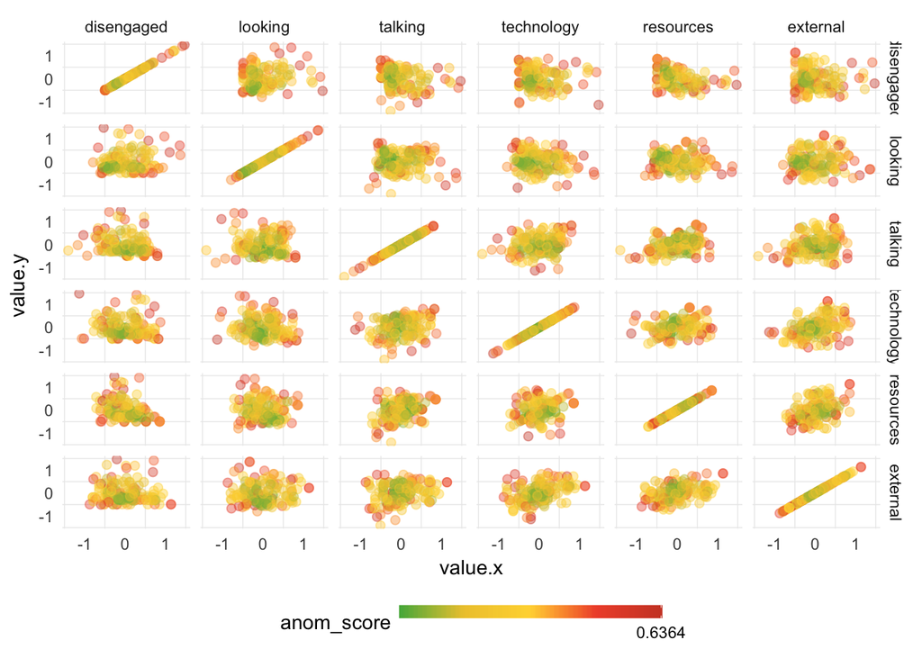

```r
dplyr::filter(if_data, is_anomaly)
```

```
## # A tibble: 8 x 9
##   global.id       disengaged looking talking technology resources external
##   <chr>                <dbl>   <dbl>   <dbl>      <dbl>     <dbl>    <dbl>
## 1 2017-10-11 Gro…      0.698   1.35  -0.503      -0.451   -0.451    -0.336
## 2 2017-10-18 Gro…      1.47   -0.531 -0.103      -1.13    -0.266    -0.205
## 3 2017-10-18 Gro…     -0.489   0.688  0.0405     -1.02     0.518    -0.205
## 4 2017-10-18 Gro…     -0.489   0.451  0.471      -0.171   -0.587    -0.875
## 5 2017-10-18 Gro…      0.911   0.578  0.471       0.727   -0.0422    0.689
## 6 2017-12-06 Gro…      0.404   1.10  -1.03        0.260   -0.559    -0.597
## 7 2017-12-06 Gro…     -0.502  -0.570  0.798       0.823   -0.0254   -0.597
## 8 2017-12-06 Gro…      0.606  -0.668 -0.675       0.604   -0.298    -0.784
## # ... with 2 more variables: anom_score <dbl>, is_anomaly <lgl>
```

A different approach is given by the functions `detect_anomaly_for_student(data, id, column = "MCAdim1")` and `detect_anomaly_for_group(data, day, grp, column = "MCAdim1")`. They both follow a so-called model approach. The advantages of the model approach is that it takes the timeseries character of the observations into account and that it only needs the data of one student or group at a time. Hence, one does not require a big data set (just the MCA dimensions in the case exhibited below) and the analysis can be performed without having collected a huge dataset. The latter can also be interpreted as a disadvantage however, as this means that model approach does not consider as much data and the anomalies are only relative to a student or group itself.

The first function of the two takes in a dataframe, a (global) id of a student and optionally a column. The second function has a day and a group instead of an id as an input. Both return a plot.

```r
detect_anomaly_for_student(processed_data, "2017-10-11 Group 2 Student E")
```

```
## frequency = 9 minutes
```

```
## trend = 15 minutes
```

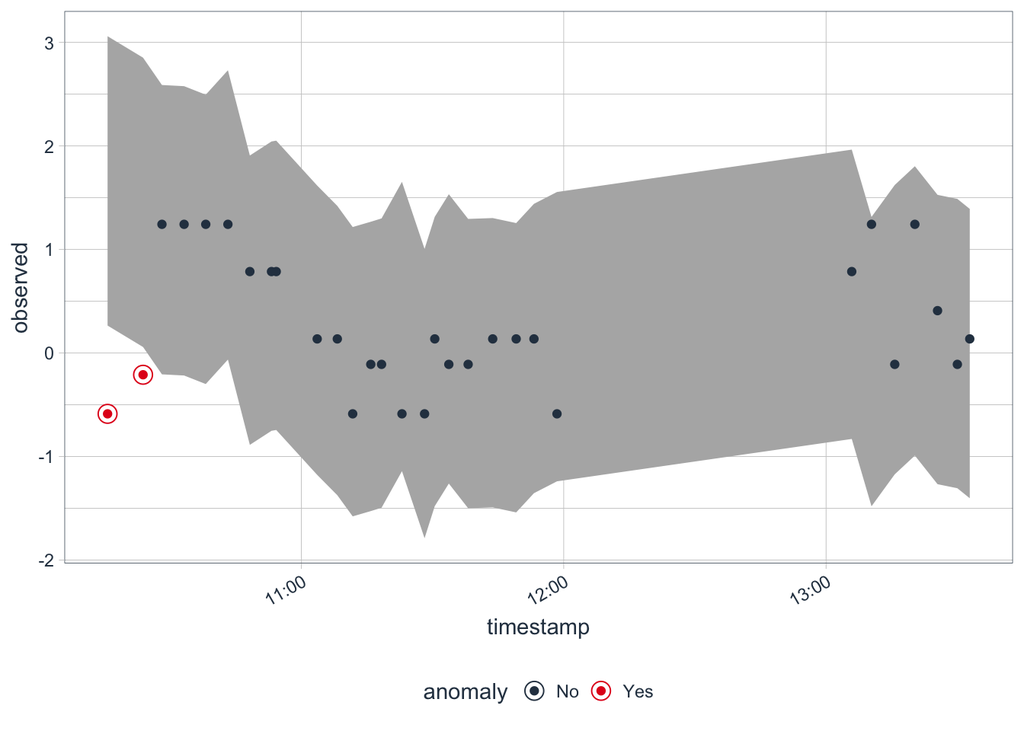

```r
detect_anomaly_for_group(processed_data, "2017-10-11", "Group 2")
```

```
## frequency = 9 minutes
## trend = 15 minutes
```

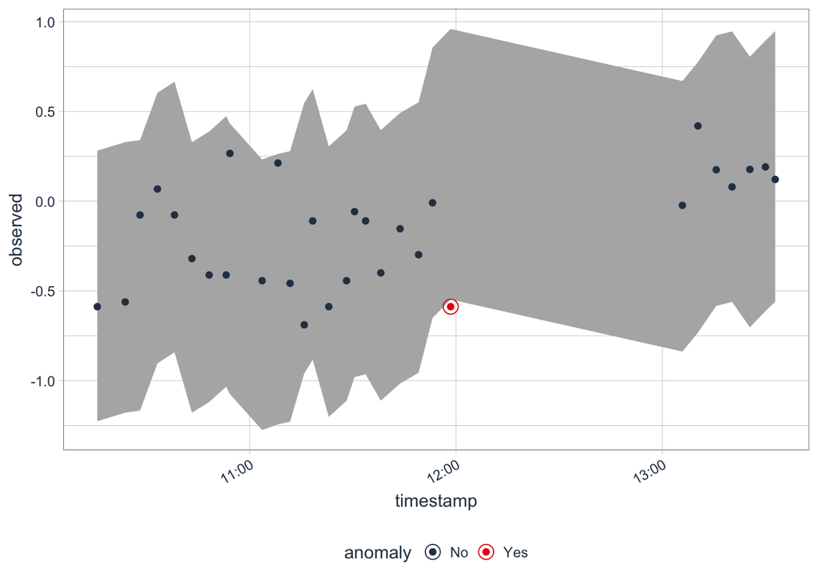